# SOLUTIONS: Multivariable logistic regression

Adjusted models, model comparison, and diagnostics for mortality after burns

GRAPH Courses team

2026-08-02

Here we set the default options used by all code chunks in this document.

# Introduction

These are the completed solutions for the Week 11 exercise. Each blank exercise chunk is shown first and not run (`eval = FALSE`), followed by a filled solution chunk that runs. The full questions and answers are included.

In Week 10 you fitted **univariable** logistic regression models for mortality after burns, following [Kim et al. (2017)](https://doi.org/10.1371/journal.pone.0185195).

This week we move to the **multivariable** half of Table 2, compare univariable models with AIC, and check model assumptions.

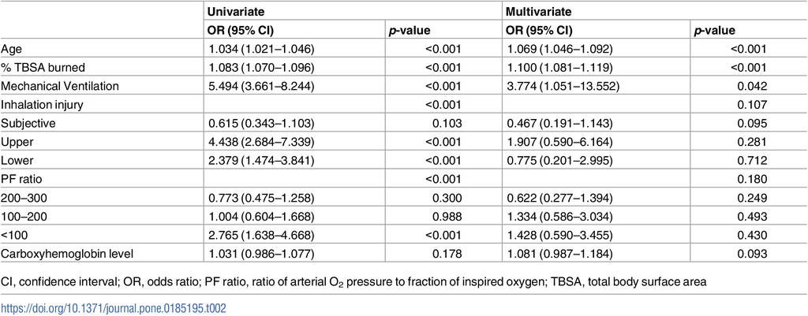

Table 2 from Kim et al. (2017).

Table 2 also reports carboxyhemoglobin. We skip that predictor here because it contains missing values. When a predictor has missing values, special considerations apply: by default, `glm()` drops every row that is missing on any variable in the formula, so the sample size can shrink and models fitted on different sets of rows are no longer directly comparable (for example with AIC). Handling missing data properly is its own topic; a useful overview is [Handling Missing Data in R](https://www.r-bloggers.com/2025/08/handling-missing-data-in-r-a-comprehensive-guide/).

Today’s goals:

1. Refit the univariable models (mostly written for you).
2. Write and interpret a multivariable logistic regression.
3. Run `check_model()` diagnostics and interpret them for a logistic model.
4. Use AIC to compare the fit of the univariable models.

# PART 1: Load and prepare the data

## Load packages

Below we load the packages used in this workshop.

```r
if (!require(pacman)) install.packages("pacman")
pacman::p_load(tidyverse, readxl, here, janitor, broom, equatiomatic, gt,
               gtsummary, performance, see)
pacman::p_load_gh("the-graph-courses/inspectdf")
```

## Import and clean

Below we import the study data and prepare the outcome and four predictors. We also keep the raw continuous PF ratio for an optional challenge at the end.

```r
burns_raw <- read_excel(here("data/S1Dataset_burns.xlsx"), sheet = "Sheet2") %>%
  clean_names()

burns <- burns_raw %>%
  rename(mortality = mortaltiy, age_years = age, tbsa_percent = tbsa) %>%
  mutate(
    mortality = factor(mortality, levels = c(0, 1),
                       labels = c("Survived", "Died")),
    inhalation_injury = factor(in_hdiv, levels = 0:3,
                               labels = c("Normal", "Subjective", "Upper", "Lower")),
    pf_ratio_group = factor(pfdivide, levels = 0:3,
                            labels = c(">300", "200-300", "100-200", "<100"))
  ) %>%
  select(mortality, age_years, tbsa_percent, inhalation_injury,
         pf_ratio, pf_ratio_group)

glimpse(burns)
```

```
## Rows: 676
## Columns: 6
## $ mortality         <fct> Survived, Survived, Survived, Died, Died, Died, Surv…
## $ age_years         <dbl> 44, 57, 59, 61, 50, 43, 52, 54, 73, 61, 45, 66, 23, …
## $ tbsa_percent      <dbl> 26, 34, 36, 32, 32, 50, 39, 11, 7, 46, 8, 6, 5, 87, …
## $ inhalation_injury <fct> Lower, Lower, Lower, Lower, Lower, Lower, Lower, Low…
## $ pf_ratio          <dbl> 278.250, 181.500, 207.250, 440.000, 152.250, 229.750…
## $ pf_ratio_group    <fct> 200-300, 100-200, 200-300, >300, 100-200, 200-300, <…
```

```r
burns %>% tabyl(mortality)
```

```
##  mortality   n   percent
##   Survived 503 0.7440828
##       Died 173 0.2559172
```

**Question 1.1:** How many patients are in the analysis dataset, and how many died?

**Answer 1.1:** 676 patients; 173 died.

**Question 1.2:** What are the four predictors we will include in the multivariable model?

**Answer 1.2:** Age, TBSA, inhalation injury, and PF ratio group.

# PART 2: Univariable models

You already know how to fit these. The code below is filled in so you can move quickly to the multivariable section. Run the chunk and skim the odds ratios.

```r
age_uni <- glm(mortality ~ age_years, family = binomial, data = burns)
tbsa_uni <- glm(mortality ~ tbsa_percent, family = binomial, data = burns)
inhalation_uni <- glm(mortality ~ inhalation_injury, family = binomial, data = burns)
pf_uni <- glm(mortality ~ pf_ratio_group, family = binomial, data = burns)

uni_results <- bind_rows(
  Age = tidy(age_uni, conf.int = TRUE, exponentiate = TRUE),
  TBSA = tidy(tbsa_uni, conf.int = TRUE, exponentiate = TRUE),
  `Inhalation injury` = tidy(inhalation_uni, conf.int = TRUE, exponentiate = TRUE),
  `PF ratio` = tidy(pf_uni, conf.int = TRUE, exponentiate = TRUE),
  .id = "predictor"
) %>%
  filter(term != "(Intercept)")

uni_results
```

```
## # A tibble: 8 × 8
##   predictor       term  estimate std.error statistic  p.value conf.low conf.high
##   <chr>           <chr>    <dbl>     <dbl>     <dbl>    <dbl>    <dbl>     <dbl>
## 1 Age             age_…    1.03    0.00618    5.36   8.16e- 8    1.02       1.05
## 2 TBSA            tbsa…    1.08    0.00614   12.9    3.32e-38    1.07       1.10
## 3 Inhalation inj… inha…    0.615   0.298     -1.63   1.03e- 1    0.333      1.08
## 4 Inhalation inj… inha…    4.44    0.257      5.81   6.38e- 9    2.69       7.37
## 5 Inhalation inj… inha…    2.38    0.244      3.55   3.90e- 4    1.47       3.83
## 6 PF ratio        pf_r…    0.773   0.249     -1.04   3.00e- 1    0.475      1.26
## 7 PF ratio        pf_r…    1.00    0.259      0.0156 9.88e- 1    0.604      1.67
## 8 PF ratio        pf_r…    2.77    0.267      3.81   1.40e- 4    1.64       4.69
```

**Question 2.1:** In the univariable results, which continuous predictors have 95% CIs that exclude 1?

**Answer 2.1:** Both continuous predictors: age and TBSA.

**Question 2.2:** Which inhalation-injury contrast (Subjective, Upper, or Lower) has the largest univariable odds ratio versus Normal?

**Answer 2.2:** Upper versus Normal (OR about 4.44).

## Compare the univariable models with AIC

AIC gives one way to compare models fitted to the same outcome and patients. A lower AIC indicates a better balance between fitting the observed data and avoiding unnecessary complexity.

Below we compare the AIC values from our four univariable models.

```r
AIC(age_uni)
```

```
## [1] 742.8202
```

```r
AIC(tbsa_uni)
```

```
## [1] 448.2986
```

```r
AIC(inhalation_uni)
```

```
## [1] 726.1729
```

```r
AIC(pf_uni)
```

```
## [1] 749.8955
```

Each AIC value above comes from one univariable model:

- `age_uni`: age (years)
- `tbsa_uni`: total body surface area burned (%)
- `inhalation_uni`: inhalation injury (Normal / Subjective / Upper / Lower)
- `pf_uni`: PF ratio group (>300 / 200-300 / 100-200 / <100)

**Question 2.3:** Which univariable model has the lowest AIC? Based on what you know clinically about burns, is that the predictor you would have expected to be strongest?

**Answer 2.3:** The TBSA model has the lowest AIC (about 448). Yes, that matches clinical expectation: burn size is usually a strong driver of mortality. This does not establish that TBSA is causal or that the model is adequate in every respect.

# PART 3: Multivariable model

Now you will fit one model that includes all four predictors together.

## Fit the model

Fill in the formula. You fill in the outcome of mortality first, then predictors separated by `+`. The order of the predictors does not change the conclusions.

*Exercise chunk (blank): Here, enter the outcome, all four predictors, and the data frame.*

```r
multivar_model <- glm(
  ________ ~ ________ + ________ + ________ + ________,
  family = binomial,
  data = ________
)
summary(multivar_model)
```

**Solution:**

Here we fit mortality on all four predictors in one multivariable logistic regression.

```r
multivar_model <- glm(
  mortality ~ age_years + tbsa_percent + inhalation_injury + pf_ratio_group,
  family = binomial,
  data = burns
)
summary(multivar_model)
```

```
##
## Call:
## glm(formula = mortality ~ age_years + tbsa_percent + inhalation_injury +
##     pf_ratio_group, family = binomial, data = burns)
##
## Coefficients:
##                             Estimate Std. Error z value Pr(>|z|)
## (Intercept)                 -8.60134    0.80435 -10.693  < 2e-16 ***
## age_years                    0.06209    0.00982   6.322 2.58e-10 ***
## tbsa_percent                 0.09036    0.00754  11.984  < 2e-16 ***
## inhalation_injurySubjective -0.99668    0.43699  -2.281 0.022561 *
## inhalation_injuryUpper       1.37314    0.41446   3.313 0.000923 ***
## inhalation_injuryLower       0.91643    0.35722   2.565 0.010305 *
## pf_ratio_group200-300       -0.31554    0.37301  -0.846 0.397590
## pf_ratio_group100-200        0.26914    0.38802   0.694 0.487926
## pf_ratio_group<100           0.54631    0.40341   1.354 0.175662
## ---
## Signif. codes:  0 '***' 0.001 '**' 0.01 '*' 0.05 '.' 0.1 ' ' 1
##
## (Dispersion parameter for binomial family taken to be 1)
##
##     Null deviance: 768.94  on 675  degrees of freedom
## Residual deviance: 358.38  on 667  degrees of freedom
## AIC: 376.38
##
## Number of Fisher Scoring iterations: 6
```

## Display the equation

Below we display the fitted multivariable logistic regression equation.

```r
extract_eq(multivar_model, use_coefs = TRUE, wrap = TRUE, terms_per_line = 3) %>%
  preview_eq()
```

[output not shown]

**Question 3.1:** How many parameters does this model have, including the intercept? (Count the coefficients in your `extract_eq()` output or the number of rows in the `summary()` output.)

**Answer 3.1:** 9 parameters (intercept + age + TBSA + 3 inhalation contrasts (Subjective, Upper, Lower) + 3 PF contrasts (200-300, 100-200, <100)).

## Odds ratios

*Exercise chunk (blank): Here, complete the `tidy()` call to request confidence intervals and exponentiated estimates.*

```r
multivar_results <- tidy(________, conf.int = ________, exponentiate = ________)
multivar_results
```

**Solution:**

Here we use `tidy()` to obtain adjusted odds ratios and 95% confidence intervals.

```r
multivar_results <- tidy(multivar_model, conf.int = TRUE, exponentiate = TRUE)
multivar_results
```

```
## # A tibble: 9 × 7
##   term                  estimate std.error statistic  p.value conf.low conf.high
##   <chr>                    <dbl>     <dbl>     <dbl>    <dbl>    <dbl>     <dbl>
## 1 (Intercept)           0.000184   0.804     -10.7   1.09e-26  3.46e-5  0.000817
## 2 age_years             1.06       0.00982     6.32  2.58e-10  1.04e+0  1.09
## 3 tbsa_percent          1.09       0.00754    12.0   4.30e-33  1.08e+0  1.11
## 4 inhalation_injurySub… 0.369      0.437      -2.28  2.26e- 2  1.51e-1  0.843
## 5 inhalation_injuryUpp… 3.95       0.414       3.31  9.23e- 4  1.76e+0  9.00
## 6 inhalation_injuryLow… 2.50       0.357       2.57  1.03e- 2  1.24e+0  5.05
## 7 pf_ratio_group200-300 0.729      0.373      -0.846 3.98e- 1  3.50e-1  1.52
## 8 pf_ratio_group100-200 1.31       0.388       0.694 4.88e- 1  6.12e-1  2.82
## 9 pf_ratio_group<100    1.73       0.403       1.35  1.76e- 1  7.84e-1  3.83
```

**Question 3.2:** Complete the interpretation for age in the multivariable model.

**Answer 3.2:**

> After adjusting for TBSA, inhalation injury, and PF ratio group, each additional year of age was associated with about **1.06** times the odds of mortality (OR **1.06**, 95% CI **1.04** to **1.09**).

**Question 3.3:** Compare the univariable and multivariable ORs for Upper inhalation injury (versus Normal). Complete the interpretation below.

**Answer 3.3:**

> The OR decreased from about **4.44** in the univariable model to about **3.95** after adjustment, so it moved **closer to** 1. This suggests that differences in age, TBSA, and PF ratio may explain **some** of the univariable association. However, the adjusted OR remains well above 1, so **most** of the association remains after adjustment.

**Question 3.4:** In the multivariable model, which predictors still have statistically significant associations with mortality (CI excludes 1, or p < 0.05)?

**Answer 3.4:** Age, TBSA, Subjective inhalation (vs Normal; lower odds), Upper inhalation (vs Normal; higher odds), and Lower inhalation (vs Normal; higher odds). The PF ratio contrasts (200-300, 100-200, <100) are not significant after adjustment.

## Side-by-side univariable and multivariable table

Below we use some functions from the `gtsummary` package to create a side-by-side table of the univariable and multivariable results.

The `tbl_uvregression()` function fits one separate univariable model for every selected predictor and combines the results into one table. The `tbl_regression()` function formats the results from one fitted model. The `tbl_merge()` function then places our univariable and adjusted tables side by side.

Below we create the univariable and adjusted tables, then merge them.

```r
crude_table <- burns %>%
  select(mortality, age_years, tbsa_percent, inhalation_injury, pf_ratio_group) %>%
  tbl_uvregression(
    y = mortality,
    method = glm,
    method.args = list(family = binomial),
    label = list(
      age_years ~ "Age (years)",
      tbsa_percent ~ "TBSA burned (%)",
      inhalation_injury ~ "Inhalation injury",
      pf_ratio_group ~ "PF ratio group"
    ),
    exponentiate = TRUE
  )

adjusted_table <- tbl_regression(
  multivar_model,
  label = list(
    age_years ~ "Age (years)",
    tbsa_percent ~ "TBSA burned (%)",
    inhalation_injury ~ "Inhalation injury",
    pf_ratio_group ~ "PF ratio group"
  ),
  exponentiate = TRUE
)

tbl_merge(
  list(crude_table, adjusted_table),
  tab_spanner = c(
    "**Univariable OR (95% CI)**",
    "**Adjusted OR (95% CI)**"
  )
)
```

| **Characteristic** | **Univariable OR (95% CI)** **N** | **Univariable OR (95% CI)** **OR** | **Univariable OR (95% CI)** **95% CI** | **Univariable OR (95% CI)** **p-value** | **Adjusted OR (95% CI)** **OR** | **Adjusted OR (95% CI)** **95% CI** | **Adjusted OR (95% CI)** **p-value** |
| --- | --- | --- | --- | --- | --- | --- | --- |
| Age (years) | 676 | 1.03 | 1.02, 1.05 | <0.001 | 1.06 | 1.04, 1.09 | <0.001 |
| TBSA burned (%) | 676 | 1.08 | 1.07, 1.10 | <0.001 | 1.09 | 1.08, 1.11 | <0.001 |
| Inhalation injury | 676 |  |  |  |  |  |  |
| Normal |  | — | — |  | — | — |  |
| Subjective |  | 0.62 | 0.33, 1.08 | 0.10 | 0.37 | 0.15, 0.84 | 0.023 |
| Upper |  | 4.44 | 2.69, 7.37 | <0.001 | 3.95 | 1.76, 9.00 | <0.001 |
| Lower |  | 2.38 | 1.47, 3.83 | <0.001 | 2.50 | 1.24, 5.05 | 0.010 |
| PF ratio group | 676 |  |  |  |  |  |  |
| >300 |  | — | — |  | — | — |  |
| 200-300 |  | 0.77 | 0.47, 1.26 | 0.3 | 0.73 | 0.35, 1.52 | 0.4 |
| 100-200 |  | 1.00 | 0.60, 1.67 | >0.9 | 1.31 | 0.61, 2.82 | 0.5 |
| <100 |  | 2.77 | 1.64, 4.69 | <0.001 | 1.73 | 0.78, 3.83 | 0.2 |

Abbreviations: CI = Confidence Interval, OR = Odds Ratio

# PART 4: Assumption checks for logistic regression

In Week 9 you used the SUNSHINE checklist for **linear** regression. Many of the same ideas apply to logistic regression, with a few important differences.

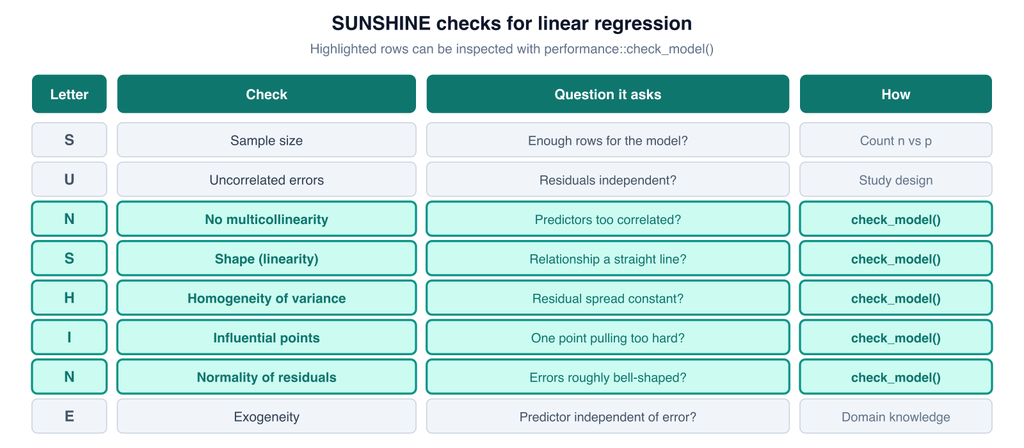

## What changes for logistic models?

| Check | Linear regression | Logistic regression |
| --- | --- | --- |
| Sample size | Rough guideline often uses total rows $n$ vs number of parameters | Rough guideline usually counts **events** (the rarer outcome class) vs number of parameters |
| Shape | Residual vs fitted should look flat (linear mean) | Relationship should be roughly **linear in the log-odds**. `check_model()` shows **binned residuals** for this |
| Homogeneity | Residual spread should be constant | **Not an assumption** of logistic regression. |
| Normality of residuals | Often checked, least critical in large samples | **Not an assumption** of logistic regression. |
| Multicollinearity, influence, design | Same ideas | Same ideas |

**Question 4.1:** For logistic regression, a common rough guideline is at least about 10 **events** (here, deaths) per model parameter, not 10 rows. With 173 deaths and 9 parameters, do we meet this guideline?

**Answer 4.1:** Yes. With 173 deaths and 9 parameters, we have about 19 events per parameter, which is above the rough guideline of 10. (Total $n = 676$ is larger, but for logistic models the limiting count is usually the rarer outcome class.)

**Question 4.2:** Does logistic regression require normally distributed residuals?

**Answer 4.2:** No. Normal residuals are not an assumption of logistic regression.

**Question 4.3:** For a logistic model, which `check_model()` diagnostic panel is used to check whether the model shape is a good fit for the data?

**Answer 4.3:** The binned-residual panel.

## Run `check_model()`

Below we run the diagnostic panel for our multivariable model.

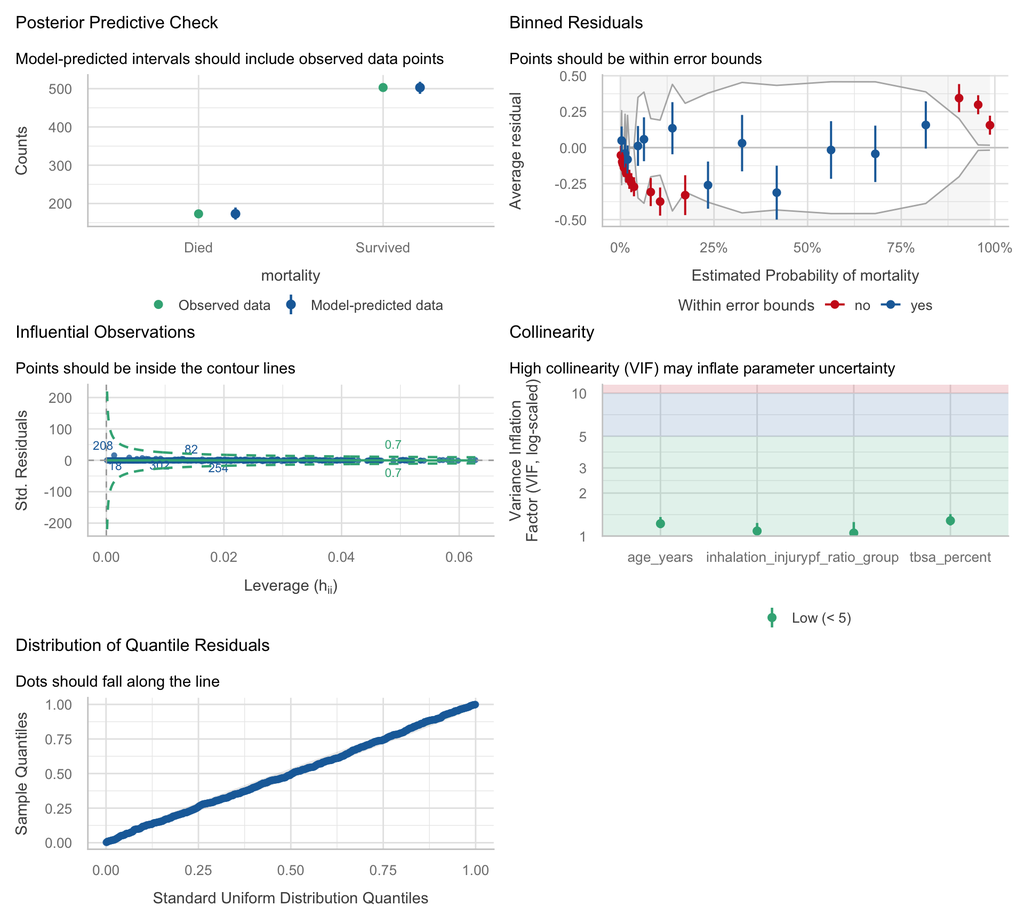

```r
check_model(multivar_model)
```

**Question 4.4:** Is there any concern about collinearity (high VIF), or influential observations based on the output?

**Answer 4.4:** No. The VIF values are low, and no observations appear sufficiently influential to dominate the fitted model.

### Binned-residual plot

The binned-residual plot shows some concerning trends. Many binned average residuals lie outside their error bounds. This suggests systematic lack of fit in parts of the prediction range.

For a good fitting model, we would expect about 95% of the binned averages to fall inside the bounds.

Possible causes include a non-linear continuous effect, an omitted predictor, or a missing interaction. Useful next steps could include checking different functional forms for the continuous predictors, and considering clinically plausible interactions or omitted predictors. This is outside the scope of this lesson, but you may choose to explore these ideas in your own time.

This possible lack of fit should also be reported. The original paper did not report model diagnostics, so we cannot tell whether the authors noticed the same concern.

# Final reporting task

Complete the results paragraph below using the multivariable model.

**Answer:**

> We fitted a multivariable logistic regression model of in-hospital mortality among 676 patients. After adjustment, each additional year of age was associated with an odds ratio of **1.064** (95% CI 1.044 to 1.085), and each additional percentage point of TBSA burned with an odds ratio of **1.095** (95% CI 1.079 to 1.112). Compared with Normal inhalation status, Upper injury had an adjusted odds ratio of **3.948** and Lower injury **2.500**. None of the PF ratio comparisons reached statistical significance after adjustment; the largest adjusted odds ratio was **1.727** for <100 versus >300.

> We also checked the model diagnostics. Collinearity between the predictors was **low**, and **no** observations appeared unduly influential. However, many binned average residuals fell **outside** their expected bounds, which suggests that the model **does not fit** parts of the prediction range well. We report this as a limitation of the analysis.

# Optional challenge: Continuous or categorized PF ratio?

The paper used four PF ratio categories instead of modeling the continuous variable directly. Categorizing loses information within groups and creates abrupt cut points, but can sometimes fit the data better than a pure continuous predictor. It can also make clinical decisions easier.

Below we compare the AIC values from our two PF ratio models to see which one fits the data better.

Compare `pf_uni` (categorized) with a new model using raw continuous `pf_ratio`. Fit the continuous model below and compare AIC values.

*Exercise chunk (blank): Here, enter the outcome, continuous PF-ratio predictor, family, and data frame.*

```r
pf_continuous_model <- glm(________ ~ ________, family = ________, data = ________)

AIC(pf_continuous_model)
AIC(pf_uni)
```

**Solution:**

Here we fit mortality on raw PF ratio and compare its AIC with the categorized model.

```r
pf_continuous_model <- glm(mortality ~ pf_ratio, family = binomial, data = burns)

AIC(pf_continuous_model)
```

```
## [1] 753.7732
```

```r
AIC(pf_uni)
```

```
## [1] 749.8955
```

**Challenge question 1:** Which model has the lower AIC, and by approximately how many points?

**Answer:** The categorized model has the lower AIC: about **749.9**, compared with **753.8** for the continuous model. The difference is approximately **3.9 AIC points**.

**Challenge question 2:** Is the AIC difference very large? Based on this comparison, does the categorization of PF ratio which the authors implemented appear to have improved the model fit?

**Answer:** The difference is modest (about 4 AIC points). Yes, categorization appears to have improved the fit slightly, but not dramatically.

# Reference

Kim Y, Kym D, Hur J, Yoon J, Yim H, Cho YS, et al. (2017). Does inhalation injury predict mortality in burns patients or require redefinition? *PLOS ONE*, 12(9), e0185195. https://doi.org/10.1371/journal.pone.0185195